# PracticalMachineLearning

Evgieni Gordienko

December 21, 2014

# Practical Machine Learning - Prediction Assignment Writeup

Background and Task

Using devices such as Jawbone Up, Nike FuelBand, and Fitbit it is now possible to collect a l arge amount of data about personal activity relatively inexpensively. These type of devices are part of the quantified self movement – a group of enthusiasts who take measurements about themselves regularly to improve their health, to find patterns in their behavior, or because they are tech geeks. One thing that people regularly do is quantify how much of a particular activity they do, but they rarely quantify how well they do it. In this project, your goal will be to use data from accelerometers on the belt, forearm, arm, and dumbell of 6 participants. They were asked to perform barbell lifts correctly and incorrectly in 5 different ways. More information is available from the website here: http://groupware.les.inf.puc-rio.br/har (see the section on the Weight Lifting Exercise Dataset).

Data sources (copied to local RStudio project folder):

The training data for this project are available here: https://d396qusza40orc.cloudfront.net/predmachlearn/pml-training.csv

The test data are available here: https://d396qusza40orc.cloudfront.net/predmachlearn/pml-testing.csv

Since training data contains some garbage in form #DIV/0! we have to substitute it with NA.

```r
training_data_source <- read.csv("pml-training.csv", na.strings=c("#DIV/0!") )
testing_data_source <- read.csv("pml-testing.csv", na.strings=c("#DIV/0!") )
```

Loading base libraries:

```r
library(Hmisc); library(caret);
```

Data preparation and partitioning:

```r
set.seed(12345)
inTrain <- createDataPartition(y=training_data_source$classe, p=0.9, list=FALSE)
training <- training_data_source[inTrain,]
testing <- training_data_source[-inTrain,]
```

Cleaning the data - remove near zero covariates:

```r
nearZero <- nearZeroVar(training, saveMetrics=TRUE)
```

To find out the list of column names for near zero covariates we use:

```r
nearZero
```

```
##                            freqRatio percentUnique zeroVar   nzv
## X                           1.000000  1.000000e+02   FALSE FALSE
## user_name                   1.112232  3.397124e-02   FALSE FALSE
## raw_timestamp_part_1        1.000000  4.738988e+00   FALSE FALSE
## raw_timestamp_part_2        1.000000  8.671725e+01   FALSE FALSE
## cvtd_timestamp              1.006677  1.132375e-01   FALSE FALSE
## new_window                 47.925208  1.132375e-02   FALSE  TRUE
## num_window                  1.000000  4.857887e+00   FALSE FALSE
## roll_belt                   1.098259  7.162269e+00   FALSE FALSE
## pitch_belt                  1.039773  1.017439e+01   FALSE FALSE
## yaw_belt                    1.069717  1.078021e+01   FALSE FALSE
## total_accel_belt            1.054135  1.641943e-01   FALSE FALSE
## kurtosis_roll_belt          2.000000  1.987317e+00   FALSE FALSE
## kurtosis_picth_belt         1.333333  1.602310e+00   FALSE FALSE
## kurtosis_yaw_belt           0.000000  0.000000e+00    TRUE  TRUE
## skewness_roll_belt          2.000000  1.975994e+00   FALSE FALSE
## skewness_roll_belt.1        1.000000  1.698562e+00   FALSE FALSE
## skewness_yaw_belt           0.000000  0.000000e+00    TRUE  TRUE
## max_roll_belt            1572.818182  1.024799e+00   FALSE  TRUE
## max_picth_belt            205.964286  1.245612e-01   FALSE  TRUE
## max_yaw_belt                1.080000  3.736836e-01   FALSE FALSE
## min_roll_belt            1572.818182  9.568565e-01   FALSE  TRUE
## min_pitch_belt            174.757576  9.625184e-02   FALSE  TRUE
## min_yaw_belt                1.080000  3.736836e-01   FALSE FALSE
## amplitude_roll_belt       443.615385  7.586910e-01   FALSE  TRUE
## amplitude_pitch_belt       88.723077  7.360435e-02   FALSE  TRUE
## amplitude_yaw_belt          0.000000  5.661873e-03    TRUE  TRUE
## var_total_accel_belt      173.010000  3.510361e-01   FALSE  TRUE
## avg_roll_belt            1153.400000  1.002152e+00   FALSE  TRUE
## stddev_roll_belt          346.020000  3.793455e-01   FALSE  TRUE
## var_roll_belt             149.146552  5.095686e-01   FALSE  TRUE
## avg_pitch_belt           1922.333333  1.143698e+00   FALSE  TRUE
## stddev_pitch_belt         283.622951  2.434605e-01   FALSE  TRUE
## var_pitch_belt            166.355769  3.397124e-01   FALSE  TRUE
## avg_yaw_belt             1730.100000  1.251274e+00   FALSE  TRUE
## stddev_yaw_belt           230.680000  3.114030e-01   FALSE  TRUE
## var_yaw_belt              288.350000  7.586910e-01   FALSE  TRUE
## gyros_belt_x                1.054873  7.756766e-01   FALSE FALSE
## gyros_belt_y                1.133797  3.906692e-01   FALSE FALSE
## gyros_belt_z                1.077116  9.455328e-01   FALSE FALSE
```

[output cut: 106 more lines]

```
## stddev_pitch_forearm      233.797297  1.630619e+00   FALSE  TRUE
## var_pitch_forearm         233.797297  1.636281e+00   FALSE  TRUE
## avg_yaw_forearm           233.797297  1.636281e+00   FALSE  TRUE
## stddev_yaw_forearm        227.644737  1.624958e+00   FALSE  TRUE
## var_yaw_forearm           227.644737  1.624958e+00   FALSE  TRUE
## gyros_forearm_x             1.065539  1.675914e+00   FALSE FALSE
## gyros_forearm_y             1.067251  4.167138e+00   FALSE FALSE
## gyros_forearm_z             1.116173  1.709886e+00   FALSE FALSE
## accel_forearm_x             1.112500  4.484203e+00   FALSE FALSE
## accel_forearm_y             1.168675  5.639225e+00   FALSE FALSE
## accel_forearm_z             1.021583  3.227268e+00   FALSE FALSE
## magnet_forearm_x            1.041667  8.532443e+00   FALSE FALSE
## magnet_forearm_y            1.263889  1.054807e+01   FALSE FALSE
## magnet_forearm_z            1.037736  9.421357e+00   FALSE FALSE
## classe                      1.469280  2.830936e-02   FALSE FALSE
```

To speed Up calculations by parallel execution we use:

```r
library(doMC)
registerDoMC(cores = 6)
```

(my box has 8 cores detected)

After filtering near zero covariates out we can train on remaining columns. We use Random Forest model due to its good ability to estimate the importance of each predictor variable in modeling the response variable.

```r
library(randomForest)
modFit <- randomForest(classe ~ user_name + pitch_arm + yaw_arm + roll_arm + roll_belt
+ pitch_belt + yaw_belt + gyros_belt_x + gyros_belt_y + gyros_belt_z + accel_belt_x
+ accel_belt_y + accel_belt_z + magnet_belt_x + magnet_belt_y + magnet_belt_z
+ gyros_arm_x + gyros_arm_y + gyros_arm_z + accel_arm_x + accel_arm_y + accel_arm_z
+ magnet_arm_x + magnet_arm_y + magnet_arm_z + roll_dumbbell + pitch_dumbbell
+ yaw_dumbbell, importance = TRUE,data=training, keep.forest=TRUE)

modFit
```

```
##
## Call:
##  randomForest(formula = classe ~ user_name + pitch_arm + yaw_arm +      roll_arm + roll_belt + pitch_belt + yaw_belt + gyros_belt_x +      gyros_belt_y + gyros_belt_z + accel_belt_x + accel_belt_y +      accel_belt_z + magnet_belt_x + magnet_belt_y + magnet_belt_z +      gyros_arm_x + gyros_arm_y…
##                Type of random forest: classification
##                      Number of trees: 500
## No. of variables tried at each split: 5
##
##         OOB estimate of  error rate: 1.34%
## Confusion matrix:
##      A    B    C    D    E class.error
## A 4961   14   14   22   11 0.012146555
## B   32 3365   19    2    0 0.015506144
## C    8   24 3031   16    1 0.015909091
## D    7    0   42 2842    4 0.018307427
## E    5    7    3    6 3226 0.006467508
```

Now verify predictions on testing partition:

```r
predictTst<-predict(modFit, testing); confusionMatrix(predictTst, testing$classe);
```

```
## Confusion Matrix and Statistics
##
##           Reference
## Prediction   A   B   C   D   E
##          A 554   3   1   0   1
##          B   2 374   6   0   0
##          C   0   2 332   4   2
##          D   2   0   3 316   0
##          E   0   0   0   1 357
##
## Overall Statistics
##
##                Accuracy : 0.9862
##                  95% CI : (0.98, 0.9909)
##     No Information Rate : 0.2847
##     P-Value [Acc > NIR] : < 2.2e-16
##
##                   Kappa : 0.9826
##  Mcnemar's Test P-Value : NA
##
## Statistics by Class:
##
##                      Class: A Class: B Class: C Class: D Class: E
## Sensitivity            0.9928   0.9868   0.9708   0.9844   0.9917
## Specificity            0.9964   0.9949   0.9951   0.9969   0.9994
## Pos Pred Value         0.9911   0.9791   0.9765   0.9844   0.9972
## Neg Pred Value         0.9971   0.9968   0.9938   0.9969   0.9981
## Prevalence             0.2847   0.1934   0.1745   0.1638   0.1837
## Detection Rate         0.2827   0.1908   0.1694   0.1612   0.1821
## Detection Prevalence   0.2852   0.1949   0.1735   0.1638   0.1827
## Balanced Accuracy      0.9946   0.9909   0.9829   0.9907   0.9955
```

Check accuracy:

```r
accuracy <- postResample(predictTst, testing$classe)
accuracy
```

```
##  Accuracy     Kappa
## 0.9862245 0.9825732
```

Now Check importance of covariates:

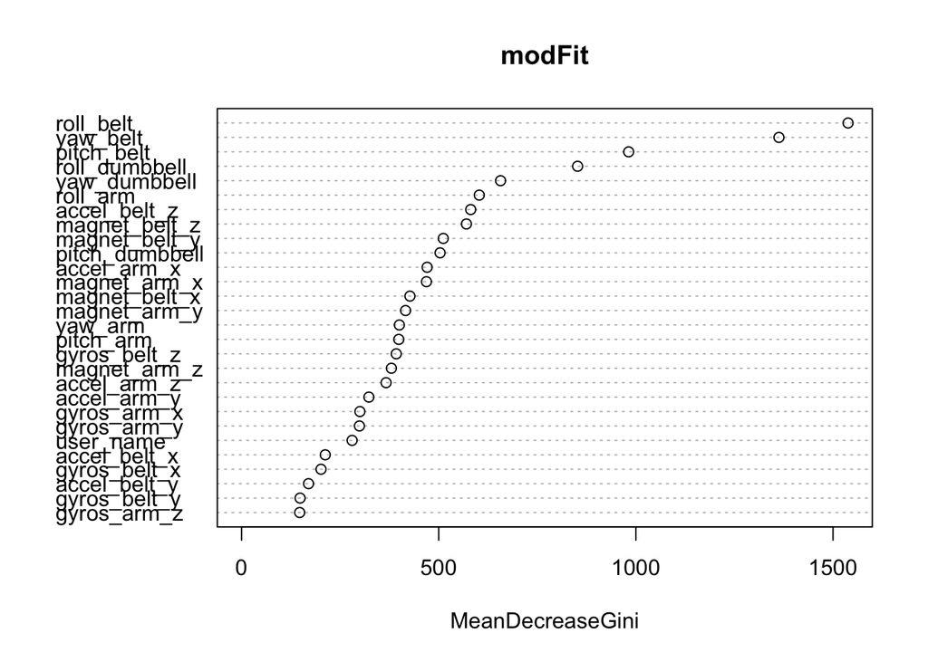

```r
varImpPlot(modFit, type=2)
```

roll_belt and yaw_belt are the leaders.

Cross validation and error estimates

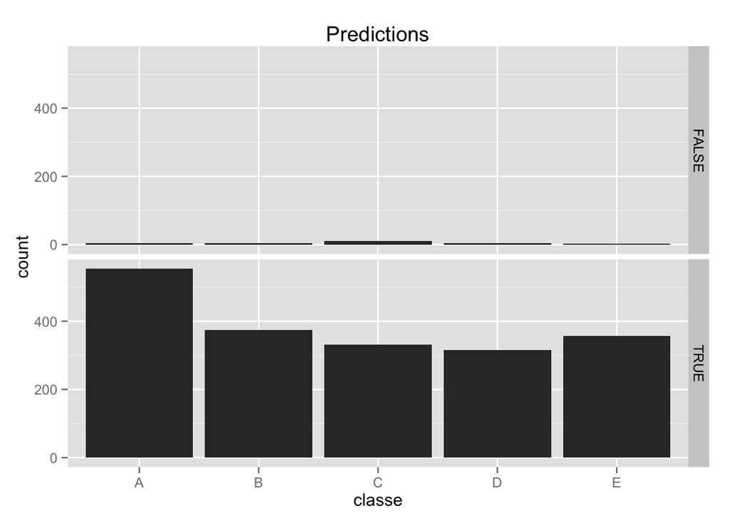

```r
library(ggplot2)
pred <- predict(modFit, testing); testing$predRight <- pred==testing$classe;
qplot(classe, data=testing, main="Predictions") +  facet_grid(predRight ~ .)
```

Verified that no overfitting.

Validate model on supplied separate testing_data_source:

```r
predict_validation<- predict(modFit, testing_data_source)
predict_validation
```

```
##  1  2  3  4  5  6  7  8  9 10 11 12 13 14 15 16 17 18 19 20
##  B  A  B  A  A  E  D  B  A  A  B  C  B  A  E  E  A  B  B  B
## Levels: A B C D E
```

FINAL: put the data into a format ready for the Submission phase of the assignment. The prediction should have work as scored 20/20. Use supp;ied by COURSERA function:

```r
pml_write_files = function(x){
   n = length(x)
   for(i in 1:n){
     filename = paste0("./submit/problem_id_",i,".txt")
     write.table(x[i],file=filename,quote=FALSE,row.names=FALSE,col.names=FALSE)
   }
 }
```

Run function and produce output

```r
pml_write_files(predict_validation)
```

Confirmed after upload of answers in submit folder to Coursera that it is 20/20 scored.